# Exam 2

Ian Taylor Booth

March 22, 2021

1. Import this dataset into R and inspect the first several rows of your data

```r
dat <- read.csv("Exam 2 Data.csv")
head(dat)
```

```
##    y          x1          x2 x3
## 1  2  1.37034210 -0.66615843  b
## 2  2 -0.70417232 -0.03705622  c
## 3  4 -0.04223752 -1.53148692  c
## 4  9 -0.56711072 -0.06529335  b
## 5  1  0.31189773  0.81650472  a
## 6 13 -0.35994479 -0.80042308  b
```

2.Fit a poisson model that assumes your response is a function of x1, x2, and x3. include an interaction betwene variable x1 and x2 only

```r
fit_poiss <- glm(y ~ x1 * x2 + x3, family = poisson, data = dat)
summary(fit_poiss)
```

```
##
## Call:
## glm(formula = y ~ x1 * x2 + x3, family = poisson, data = dat)
##
## Deviance Residuals:
##     Min       1Q   Median       3Q      Max
## -2.3620  -0.6973  -0.1007   0.5236   2.6779
##
## Coefficients:
##             Estimate Std. Error z value Pr(>|z|)
## (Intercept)  1.13258    0.08540  13.262  < 2e-16 ***
## x1          -1.03491    0.05019 -20.620  < 2e-16 ***
## x2          -0.90839    0.06977 -13.021  < 2e-16 ***
## x3b          0.37532    0.09246   4.059 4.92e-05 ***
## x3c         -0.88354    0.12072  -7.319 2.50e-13 ***
## x1:x2       -0.28868    0.05142  -5.614 1.98e-08 ***
## ---
## Signif. codes:  0 '***' 0.001 '**' 0.01 '*' 0.05 '.' 0.1 ' ' 1
##
## (Dispersion parameter for poisson family taken to be 1)
##
##     Null deviance: 720.551  on 99  degrees of freedom
## Residual deviance:  89.088  on 94  degrees of freedom
## AIC: 392.86
##
## Number of Fisher Scoring iterations: 5
```

3. Interpret the effect of variable x1 when x2=-1

Answer: The log odds of success decrease by 0.746 for every 1 unit increase in x1

```r
b <- coef(fit_poiss)
b
```

```
## (Intercept)          x1          x2         x3b         x3c       x1:x2
##   1.1325781  -1.0349058  -0.9083868   0.3753215  -0.8835413  -0.2886813
```

```r
b[2] + b[6] * -1
```

```
##         x1
## -0.7462245
```

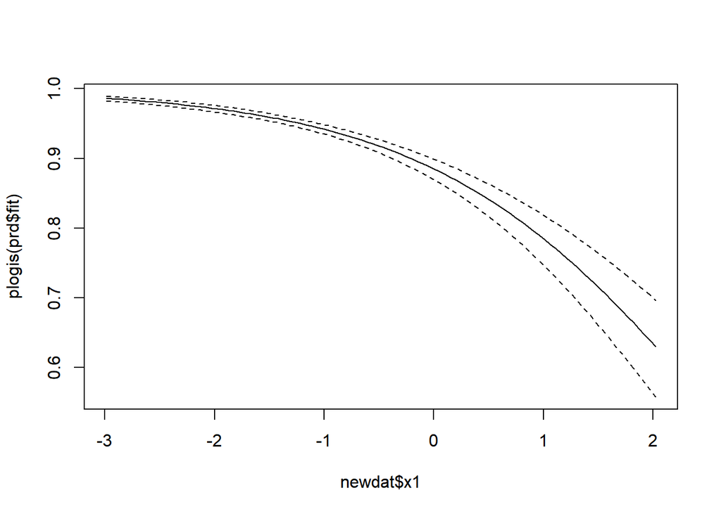

```r
newdat <- data.frame(
  x1 = seq(min(dat$x1), max(dat$x2), length.out = 100),
  x2 = -1,
  x3 = factor('a', levels = c('a', 'b', 'c'))
)

prd <- predict.glm(fit_poiss, newdat, se.fit = T)

low <- plogis(prd$fit - qnorm(0.95) * prd$se.fit)
high <- plogis(prd$fit + qnorm(0.95) * prd$se.fit)


plot(x = newdat$x1, y = plogis(prd$fit), ylim = c(min(low), max(high)) , type = 'l')
lines(x = newdat$x1, y = low, lty = 2)
lines(x = newdat$x1, y = high, lty = 2)
```

5.Interpret the effect of variable x3

Answer:The difference in log odds between category b and a is 0.375. The difference in log odds between category c and a is -0.883

```r
summary(fit_poiss)
```

```
##
## Call:
## glm(formula = y ~ x1 * x2 + x3, family = poisson, data = dat)
##
## Deviance Residuals:
##     Min       1Q   Median       3Q      Max
## -2.3620  -0.6973  -0.1007   0.5236   2.6779
##
## Coefficients:
##             Estimate Std. Error z value Pr(>|z|)
## (Intercept)  1.13258    0.08540  13.262  < 2e-16 ***
## x1          -1.03491    0.05019 -20.620  < 2e-16 ***
## x2          -0.90839    0.06977 -13.021  < 2e-16 ***
## x3b          0.37532    0.09246   4.059 4.92e-05 ***
## x3c         -0.88354    0.12072  -7.319 2.50e-13 ***
## x1:x2       -0.28868    0.05142  -5.614 1.98e-08 ***
## ---
## Signif. codes:  0 '***' 0.001 '**' 0.01 '*' 0.05 '.' 0.1 ' ' 1
##
## (Dispersion parameter for poisson family taken to be 1)
##
##     Null deviance: 720.551  on 99  degrees of freedom
## Residual deviance:  89.088  on 94  degrees of freedom
## AIC: 392.86
##
## Number of Fisher Scoring iterations: 5
```

6.Use contrasts to evaluate the null hypothesis that the difference in log expected count between levels “b” and “c” = 0. Fix x1 and x2 at their means.

Answer: Because of the small p-value (p = >2e-16) we would reject our null hypothesis that when x1 and x2 are ficed at their means then expected count levels between ‘b’ and ‘c’ = 0.

```r
library(multcomp)
m <- matrix(c(0, mean(dat$x1), mean(dat$x2), 1, -1, 0), nrow = 1)
cnt <- glht(fit_poiss, m)
summary(cnt, test = adjusted('none'))
```

```
##
##   Simultaneous Tests for General Linear Hypotheses
##
## Fit: glm(formula = y ~ x1 * x2 + x3, family = poisson, data = dat)
##
## Linear Hypotheses:
##        Estimate Std. Error z value Pr(>|z|)
## 1 == 0   1.3612     0.1212   11.23   <2e-16 ***
## ---
## Signif. codes:  0 '***' 0.001 '**' 0.01 '*' 0.05 '.' 0.1 ' ' 1
## (Adjusted p values reported -- none method)
```

7.Derive the test statistic and p-value associated with the interaction between x1 and x2. What is the null hypothesis? Do we reject or fail to reject this null hypothesis? Defend your answer

Answer: The null hypothesis is that
$$\beta_5 = 0$$
we can rewrite the equation and evaluate the expression at x2 and at x2+1. The difference between these expressions gives us:
$$\begin{split}
y_{x_1 + 1, x_2+1} - y_{x_1, x_2+1} &= \beta_1 + \beta_5(x_2+1) = \beta_1 + \beta_5x_2 + \beta_5\\
(y_{x_1 + 1, x_2+1} - y_{x_1, x_2+1}) - (y_{x_1 + 1, x_2} - y_{x_1, x_2}) & = \beta_5
\end{split}$$

Meaning
$$\beta_5 = 0$$
is the change in the effective slope of x1 associated with a 1 unit change in x2. Given our small p-value (1.98e-08), we reject the null hypothesis and can say there is evidence that the effect of variable x1 depends on the level of x2

```r
s <- summary(fit_poiss)[['coefficients']][, 2]
b[6] / s[6]
```

```
##     x1:x2
## -5.614074
```

```r
pnorm(-1 * abs(b[6] / s[6])) * 2
```

```
##        x1:x2
## 1.976182e-08
```

8.assume you have the following realizations of random variable Y : y = (1, 0) Further assume realizations of the random variable Y are Bernoulli distributed: y ∼ Bernoulli(p). What is the probability of observing each of these random variables assuming the log odds of success = -2?

Answer: I know this is wrong idk how to input the log odds = -2 or where to input. But if the porbablity is .2 then…. The probablity of observing y = 1 is .2 and the probablity of observing y = 0 is .8

```r
y <- c(1, 0)
p <- -2
dbinom((c(1, 0)), size = 1, p = .2)
```

```
## [1] 0.2 0.8
```

```r
blik <- function(p, y){sum(dbinom(y, p, log = T))}
blik
```

```
## function(p, y){sum(dbinom(y, p, log = T))}
```

9.What is the “support” of a Bernoulli random variable? What are the acceptable values of it’s sole parameter? To which quantity do we apply a link function, and why do we do this? What is the principle link function we use in binomial (i.e., logistic) regression, and what it it’s inverse function?

Answer: The support for Bernoulli random variable is the value or range of values of y, The acceptable values are 0 and 1, a link function maps a positive real number across the whole real number line and we view it as the porbablity our random vairiable will fit between 0 and 1. We use logit link function as the principal link function in binomial regression. The logit link funciton assumes x is unbounded and p is unbounded between 0 and 1.The inverse logit link function maps a number on the real line to (0,1), x is unbounded, and p is bounded bewteen 0 and 1, but in the inverse logit link funciton we are solving for p.

10. What is a fundamental assumption we make to derive inference when comparing two levels of a categorical random variable?

Answer: We calculate the difference in y between a categorical variable and a reference variable we assume that these variables share an intercept